# Codebook for DGPS workshop on Bayesian staitstics and EMA

christoph Bamberg

The first part corresponds to the models and graphs shown on the slides. At some point we switch from the slides to the code here directly. At the end there is a small exercise.

```r
library(ggplot2)
library(tidyr)
library(brms)
library(dplyr)
library(emmeans)
library(tidybayes)
theme_ppt <- function(base_size = 20, base_family = "") {
  theme_minimal(base_size = base_size, base_family = base_family) %+replace%
    theme(
      panel.grid.major = element_line(colour = "grey85", size = 0.4),
      panel.grid.minor = element_blank(),
      axis.line        = element_line(size = 0.6, colour = "black"),
      axis.ticks       = element_line(size = 0.4, colour = "black"),
      axis.title       = element_text(size = rel(1.2), face = "bold"),
      axis.text        = element_text(size = rel(1.1)),
      legend.position  = "bottom",
      legend.title     = element_text(face = "bold", size = rel(1.1)),
      legend.text      = element_text(size = rel(1)),
      legend.key       = element_blank(),
      plot.title       = element_text(size = rel(1.4), face = "bold", hjust = 0),
      plot.subtitle    = element_text(size = rel(1.2), hjust = 0),
      plot.caption     = element_text(size = rel(0.9), colour = "grey50", hjust = 1),
      strip.text       = element_text(size = rel(1.1), face = "bold")
    )
}
```

load fuction for simulation

```r
source("DGPS_WS_simulate_EMA_data.R")
?sim_EMA_data
```

```
## Keine Dokumentation für 'sim_EMA_data' in angegebenen Paketen und Bibliotheken:
## Sie können '??sim_EMA_data' versuchen
```

simulate data

```r
d=sim_EMA_data()
d
```

| id | day | prompt | prompt_index | responded | positive_mood | negative_mood | phys_activity | with_others |
| --- | --- | --- | --- | --- | --- | --- | --- | --- |
| 1 | 1 | 1 | 1 | 0 | NA | NA | NA | NA |
| 1 | 1 | 2 | 2 | 1 | 54.888811 | 16.655191 | 0.0000000 | 1 |
| 1 | 1 | 3 | 3 | 1 | 23.197462 | 34.656597 | 64.1118876 | 0 |
| 1 | 1 | 4 | 4 | 1 | 61.118183 | 21.771551 | 0.0000000 | 0 |
| 1 | 1 | 5 | 5 | 1 | 53.453962 | 23.177390 | 82.9653693 | 0 |
| 1 | 1 | 6 | 6 | 1 | 44.202249 | 24.103029 | 0.0000000 | 1 |
| 1 | 2 | 1 | 7 | 1 | 48.196886 | 36.311153 | 64.0896151 | 0 |
| 1 | 2 | 2 | 8 | 1 | 56.742475 | 26.595927 | 65.4023613 | 0 |
| 1 | 2 | 3 | 9 | 1 | 85.499274 | 35.971268 | 0.0000000 | 0 |
| 1 | 2 | 4 | 10 | 1 | 58.332596 | 28.028703 | 65.5876378 | 0 |

[output cut: 1670 more lines]

# data exploration

- distribution of data
- fitting likelihood functions

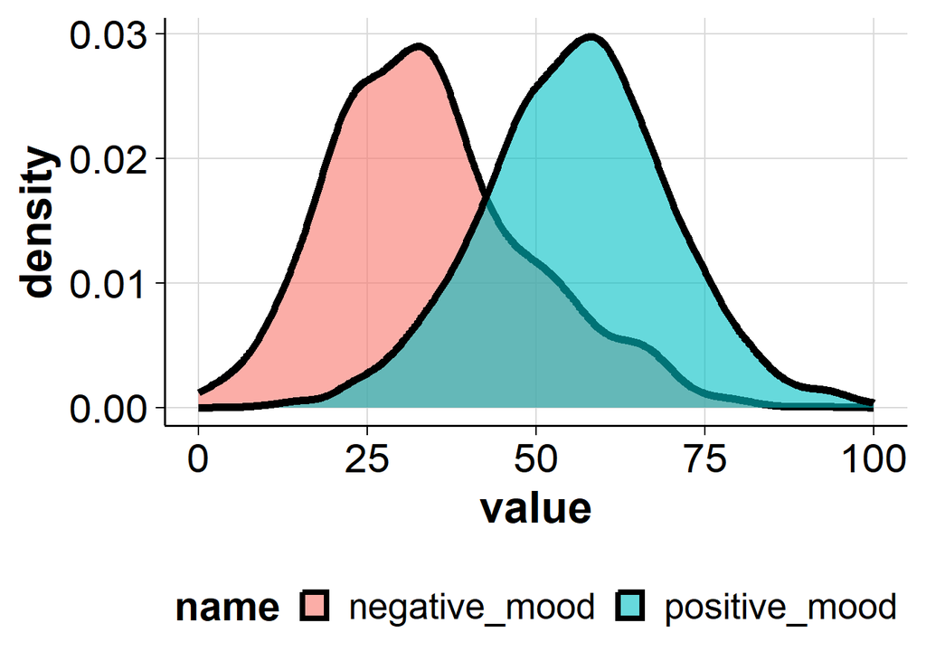

```r
d_ = pivot_longer(d,c(negative_mood,positive_mood))
ggplot(d_,aes(x=value,fill=name))+geom_density(size=2,alpha=0.6)+xlim(0,100)+theme_ppt()
```

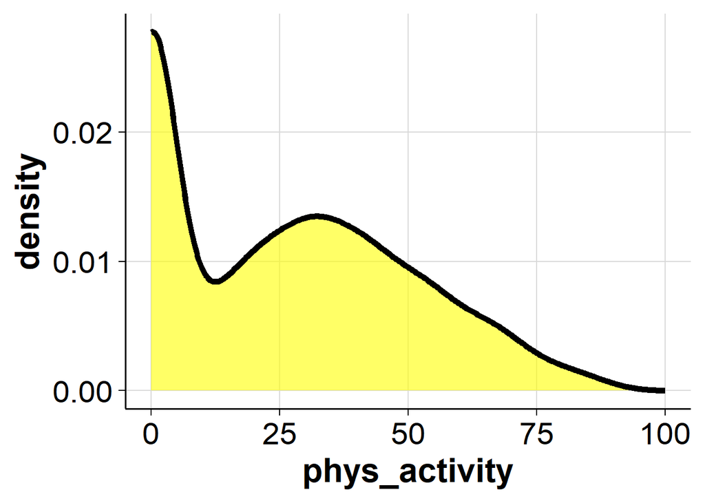

```r
ggplot(d,aes(x=phys_activity,fill=T))+geom_density(size=2,alpha=0.6,fill="yellow")+xlim(0,100)+theme_ppt()
```

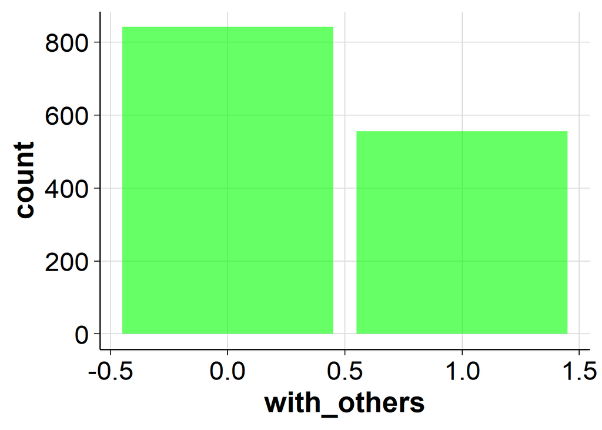

```r
ggplot(d,aes(x=with_others))+geom_bar(stat="count",size=2,alpha=0.6,fill="green")+theme_ppt()
```

# fitting linear regression

## finding priors

```r
#simple linear regression
get_prior(negative_mood ~ phys_activity,
           data=d)
```

| prior | class | coef | group | resp | dpar | nlpar | lb | ub | source |
| --- | --- | --- | --- | --- | --- | --- | --- | --- | --- |
|  | b |  |  |  |  |  |  |  | default |
|  | b | phys_activity |  |  |  |  |  |  | default |
| student_t(3, 32.6, 14) | Intercept |  |  |  |  |  |  |  | default |
| student_t(3, 0, 14) | sigma |  |  |  |  |  | 0 |  | default |

```r
# multi-level random slope & intercept model
get_prior(negative_mood ~ phys_activity + with_others + (1 + phys_activity + with_others|id/day),
           data=d)
```

| prior | class | coef | group | resp | dpar | nlpar | lb | ub | source |
| --- | --- | --- | --- | --- | --- | --- | --- | --- | --- |
|  | b |  |  |  |  |  |  |  | default |
|  | b | phys_activity |  |  |  |  |  |  | default |
|  | b | with_others |  |  |  |  |  |  | default |
| lkj(1) | cor |  |  |  |  |  |  |  | default |
|  | cor |  | id |  |  |  |  |  | default |
|  | cor |  | id:day |  |  |  |  |  | default |
| student_t(3, 32.6, 14) | Intercept |  |  |  |  |  |  |  | default |
| student_t(3, 0, 14) | sd |  |  |  |  |  | 0 |  | default |
|  | sd |  | id |  |  |  |  |  | default |
|  | sd | Intercept | id |  |  |  |  |  | default |

[output cut: 7 more lines]

exploring options for standard deviation

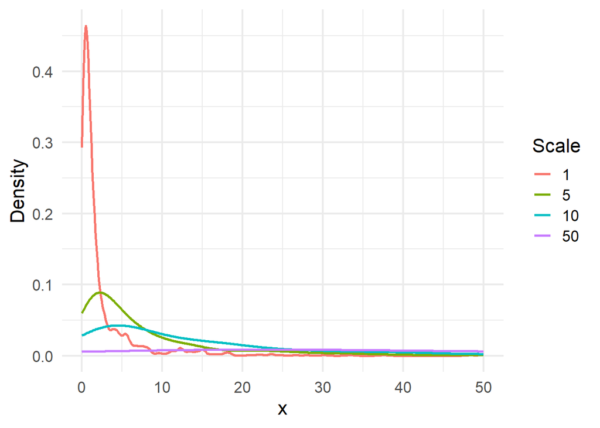

```r
n <- 1000
#scale <- 5
#x <- abs(rcauchy(n, location = 0, scale = scale))
#plot(density(x),xlim=c(0,200))


scales <- c(1, 5, 10, 50)
# simulate data and compute densities for different scale values
df <- lapply(scales, function(s) {
  x <- abs(rcauchy(n, location = 0, scale = s))
  d <- density(x, from = 0, to = 50)
  data.frame(x = d$x, y = d$y, scale = factor(s))
}) %>% bind_rows()

# plot
ggplot(df, aes(x = x, y = y, colour = scale)) +
  geom_line(size = 1) +
  labs(x = "x", y = "Density", colour = "Scale") +
  theme_minimal(base_size = 16)
```

fitting model just with prior and plotting draws from the prior distribution against the data

```r
prior_bm1 = c(prior(normal(50, 10), class = "Intercept"),
              prior(normal(0, 5),  class = "b"),
              prior(cauchy(0,5), class = "sigma"))
bm1_prior <- brm(
  negative_mood ~ phys_activity,
  data = d,
  family = gaussian(),
  prior = prior_bm1,
  sample_prior = "only",   # only sampling from prior
  iter = 2000, chains = 4, seed = 123,
  file="bm1_prior",file_refit="on_change")
summary(bm1_prior)
```

```
##  Family: gaussian
##   Links: mu = identity; sigma = identity
## Formula: negative_mood ~ phys_activity
##    Data: d (Number of observations: 1397)
##   Draws: 4 chains, each with iter = 2000; warmup = 1000; thin = 1;
##          total post-warmup draws = 4000
##
## Regression Coefficients:
##               Estimate Est.Error l-95% CI u-95% CI Rhat Bulk_ESS Tail_ESS
## Intercept        49.14    127.02  -201.17   300.96 1.00     3529     3110
## phys_activity     0.04      4.94    -9.40    10.01 1.00     3527     2834
##
## Further Distributional Parameters:
##       Estimate Est.Error l-95% CI u-95% CI Rhat Bulk_ESS Tail_ESS
## sigma    23.64    173.61     0.17   119.68 1.00     3451     2146
##
## Draws were sampled using sampling(NUTS). For each parameter, Bulk_ESS
## and Tail_ESS are effective sample size measures, and Rhat is the potential
## scale reduction factor on split chains (at convergence, Rhat = 1).
```

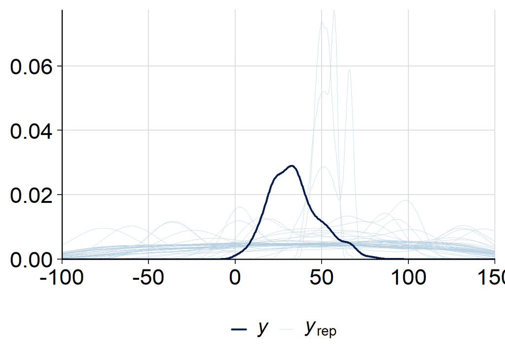

```r
p = brms::pp_check(bm1_prior,ndraws=50)
p + theme_ppt()+xlim(-100,150)
```

looks fine

## fitting model

```r
bm1<- brm(
  negative_mood ~ phys_activity,
  data = d,
  family = gaussian(),
  prior = prior_bm1, #priors from above
  iter = 2000, chains = 4, #could first fit with iter = 2 to test whether compilation is fine
  seed = 123,
  file="bm1",file_refit="on_change") #saves the model as a file, reloads it if no changes - highly recommended
```

### diagnostics

```r
summary(bm1)
```

```
##  Family: gaussian
##   Links: mu = identity; sigma = identity
## Formula: negative_mood ~ phys_activity
##    Data: d (Number of observations: 1397)
##   Draws: 4 chains, each with iter = 2000; warmup = 1000; thin = 1;
##          total post-warmup draws = 4000
##
## Regression Coefficients:
##               Estimate Est.Error l-95% CI u-95% CI Rhat Bulk_ESS Tail_ESS
## Intercept        35.02      0.60    33.86    36.18 1.00     3906     3133
## phys_activity    -0.03      0.02    -0.07    -0.00 1.00     3960     2868
##
## Further Distributional Parameters:
##       Estimate Est.Error l-95% CI u-95% CI Rhat Bulk_ESS Tail_ESS
## sigma    14.86      0.28    14.34    15.42 1.00     3760     2843
##
## Draws were sampled using sampling(NUTS). For each parameter, Bulk_ESS
## and Tail_ESS are effective sample size measures, and Rhat is the potential
## scale reduction factor on split chains (at convergence, Rhat = 1).
```

```r
#look at R-hat and ESS
```

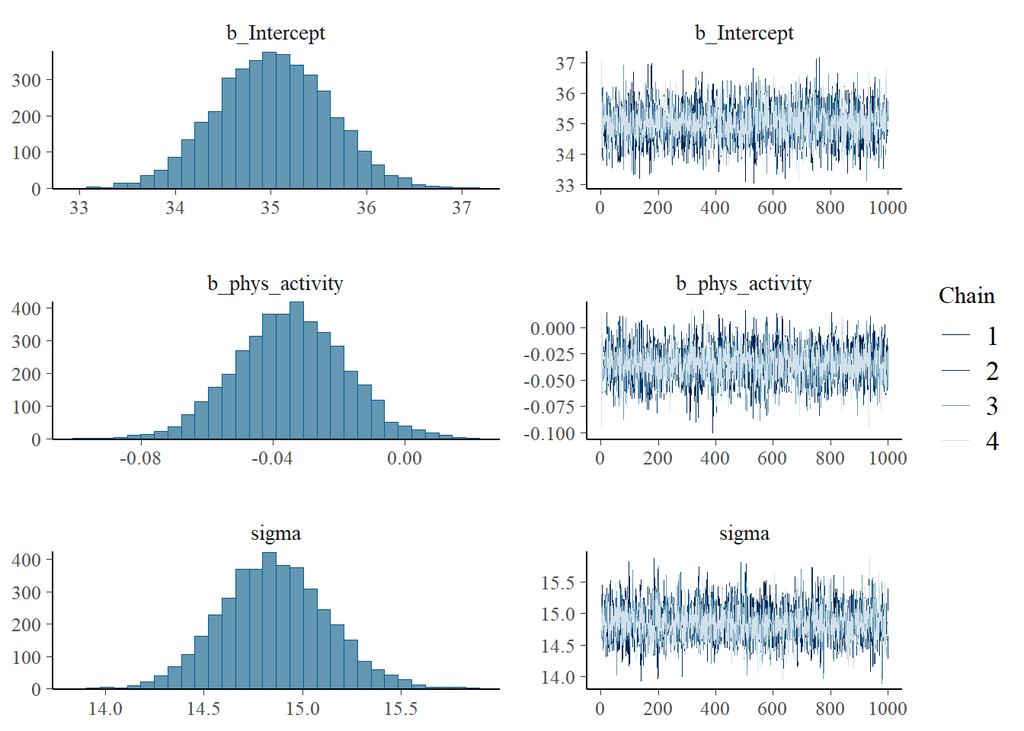

```r
plot(bm1)
```

### summary of draws

here for 90% credible interval

```r
summary(bm1, prob=0.9)
```

```
##  Family: gaussian
##   Links: mu = identity; sigma = identity
## Formula: negative_mood ~ phys_activity
##    Data: d (Number of observations: 1397)
##   Draws: 4 chains, each with iter = 2000; warmup = 1000; thin = 1;
##          total post-warmup draws = 4000
##
## Regression Coefficients:
##               Estimate Est.Error l-90% CI u-90% CI Rhat Bulk_ESS Tail_ESS
## Intercept        35.02      0.60    34.05    35.99 1.00     3906     3133
## phys_activity    -0.03      0.02    -0.06    -0.01 1.00     3960     2868
##
## Further Distributional Parameters:
##       Estimate Est.Error l-90% CI u-90% CI Rhat Bulk_ESS Tail_ESS
## sigma    14.86      0.28    14.42    15.31 1.00     3760     2843
##
## Draws were sampled using sampling(NUTS). For each parameter, Bulk_ESS
## and Tail_ESS are effective sample size measures, and Rhat is the potential
## scale reduction factor on split chains (at convergence, Rhat = 1).
```

### displaying the posterior

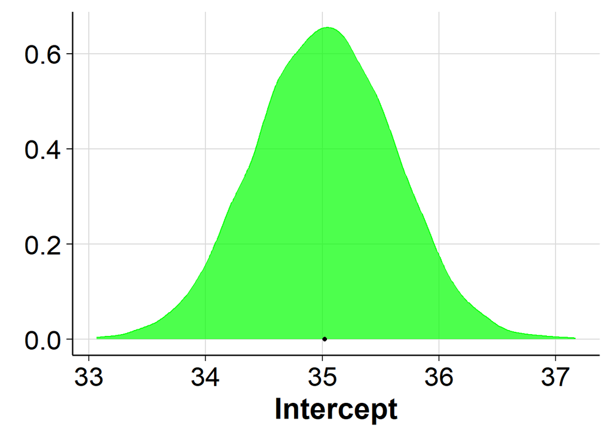

```r
#getting each of the 4000 draws as a dataframe for each sampled parameter
coeffs_bm1 = as.data.frame(bm1)

# posterior densitiy plots:
ggplot(aes(x = b_Intercept), data = coeffs_bm1) +
    geom_density(fill = "green",color = "green", alpha = 0.7) +
  geom_point(y = 0, x = mean(coeffs_bm1$b_Intercept)) +
  labs(x = "Intercept", y = element_blank()) +theme_ppt()
```

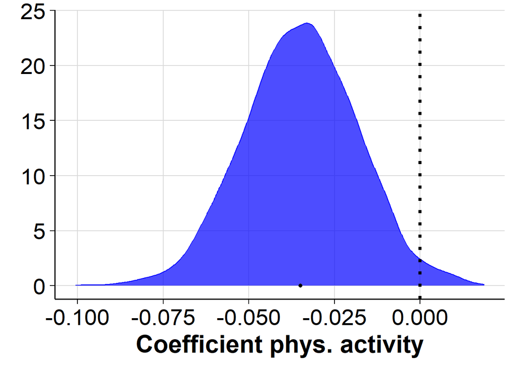

```r
ggplot(aes(x = b_phys_activity), data = coeffs_bm1) +
    geom_density(fill = "blue",color = "blue", alpha = 0.7) +
  geom_point(y = 0, x = mean(coeffs_bm1$b_phys_activity)) +
  geom_vline(xintercept=0,lty=3,lwd=1.5)+
  labs(x = "Coefficient phys. activity", y = element_blank()) +theme_ppt()
```

posterior predictive plot

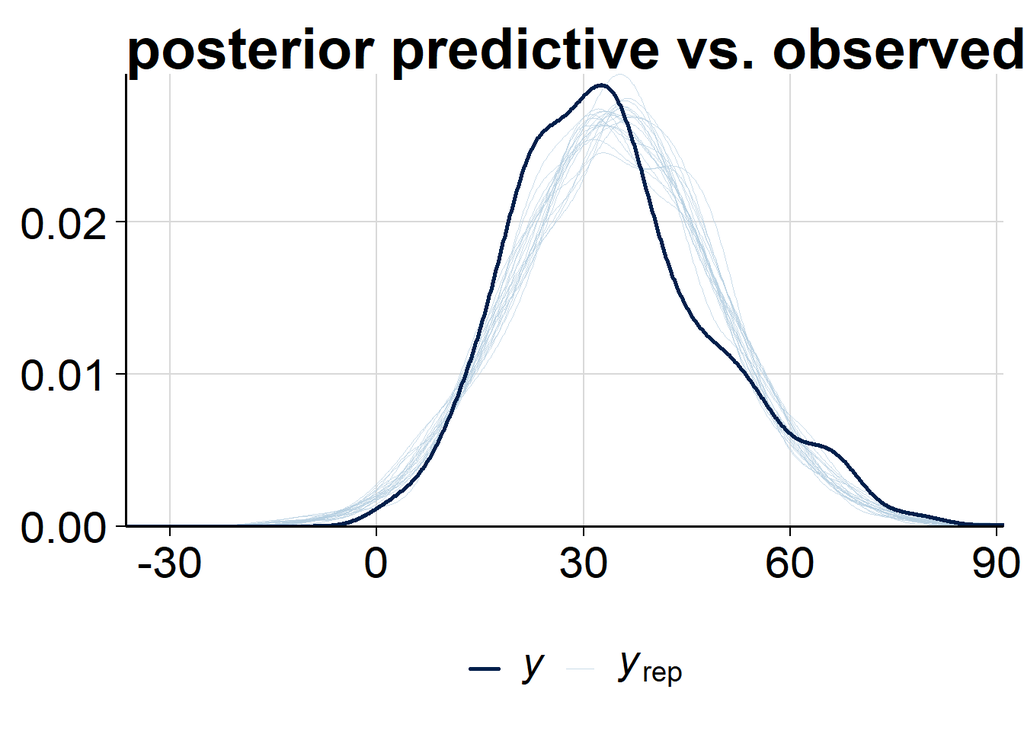

```r
pp_check(bm1, type = "dens_overlay", ndraws = 20) +
  ggtitle("posterior predictive vs. observed")+theme_ppt()
```

posterior prediction at specific value

```r
#creating new dataframe just for physical activity over 50
newdat=tibble(phys_activity = seq(50, 100, length.out = 50))
head(newdat)
```

| phys_activity |
| --- |
| 50.00000 |
| 51.02041 |
| 52.04082 |
| 53.06122 |
| 54.08163 |
| 55.10204 |

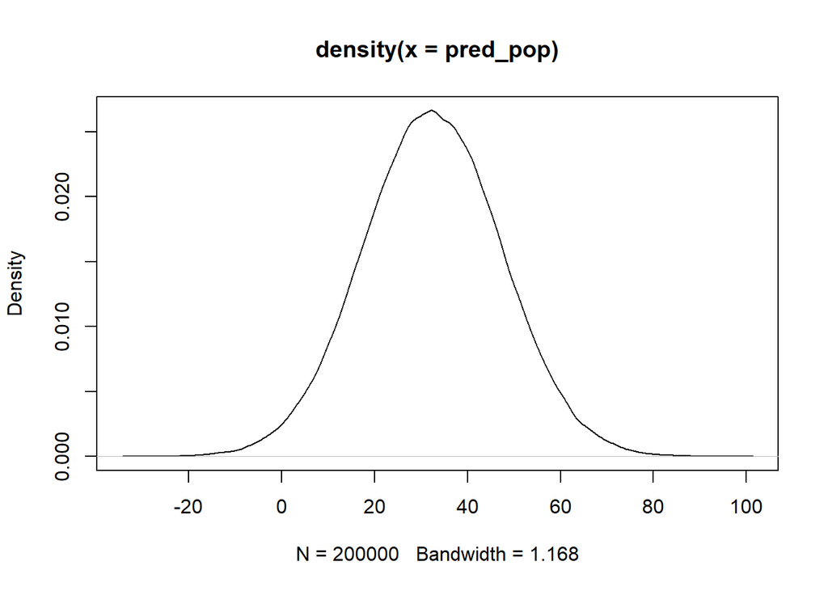

```r
#get posterior predictions
#first option: considering residual error in the whole model
pred_pop = posterior_predict(bm1, newdata = newdat)
plot(density(pred_pop))
```

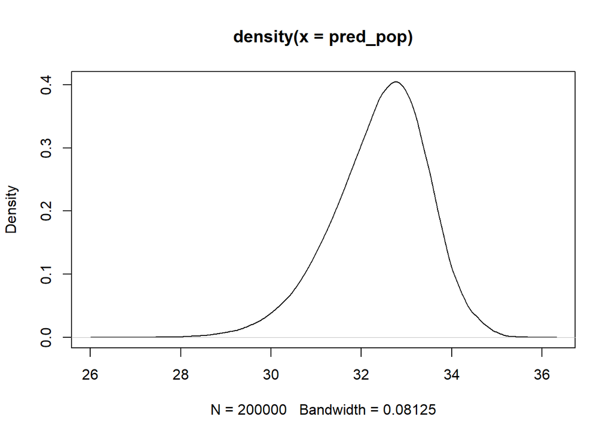

```r
# second option: only uncertainty in the expected value of the posterior prediciton considered, not residual model error
pred_pop = posterior_epred(bm1, newdata = newdat)
plot(density(pred_pop))
```

# —————————————–

# Multi-level models

```r
d
```

| id | day | prompt | prompt_index | responded | positive_mood | negative_mood | phys_activity | with_others |
| --- | --- | --- | --- | --- | --- | --- | --- | --- |
| 1 | 1 | 1 | 1 | 0 | NA | NA | NA | NA |
| 1 | 1 | 2 | 2 | 1 | 54.888811 | 16.655191 | 0.0000000 | 1 |
| 1 | 1 | 3 | 3 | 1 | 23.197462 | 34.656597 | 64.1118876 | 0 |
| 1 | 1 | 4 | 4 | 1 | 61.118183 | 21.771551 | 0.0000000 | 0 |
| 1 | 1 | 5 | 5 | 1 | 53.453962 | 23.177390 | 82.9653693 | 0 |
| 1 | 1 | 6 | 6 | 1 | 44.202249 | 24.103029 | 0.0000000 | 1 |
| 1 | 2 | 1 | 7 | 1 | 48.196886 | 36.311153 | 64.0896151 | 0 |
| 1 | 2 | 2 | 8 | 1 | 56.742475 | 26.595927 | 65.4023613 | 0 |
| 1 | 2 | 3 | 9 | 1 | 85.499274 | 35.971268 | 0.0000000 | 0 |
| 1 | 2 | 4 | 10 | 1 | 58.332596 | 28.028703 | 65.5876378 | 0 |

[output cut: 1670 more lines]

## finding priors

```r
get_prior(negative_mood ~ phys_activity + with_others + (1 + phys_activity + with_others|id),
          family=gaussian(), #is default
           data=d)
```

| prior | class | coef | group | resp | dpar | nlpar | lb | ub | source |
| --- | --- | --- | --- | --- | --- | --- | --- | --- | --- |
|  | b |  |  |  |  |  |  |  | default |
|  | b | phys_activity |  |  |  |  |  |  | default |
|  | b | with_others |  |  |  |  |  |  | default |
| lkj(1) | cor |  |  |  |  |  |  |  | default |
|  | cor |  | id |  |  |  |  |  | default |
| student_t(3, 32.6, 14) | Intercept |  |  |  |  |  |  |  | default |
| student_t(3, 0, 14) | sd |  |  |  |  |  | 0 |  | default |
|  | sd |  | id |  |  |  |  |  | default |
|  | sd | Intercept | id |  |  |  |  |  | default |
|  | sd | phys_activity | id |  |  |  |  |  | default |

[output cut: 2 more lines]

```r
prior_bm2 = c(prior(normal(50,10), class = Intercept),
            prior(normal(0,5), class = b),
            prior(cauchy(0,5), class = sigma),
            prior(cauchy(0,5), class = sd),
            prior(lkj_corr_cholesky(1), class = cor))
```

## specifying model

here, just testing the compilation and whether the summary is as expected

```r
bm2i = brm(negative_mood ~ phys_activity + with_others + (1 + phys_activity + with_others|id),
          prior=prior_bm2,
          data=d,
          chains=1,iter=2,
          file="bm2i",file_refit="on_change")
summary(bm2i)
```

```
##  Family: gaussian
##   Links: mu = identity; sigma = identity
## Formula: negative_mood ~ phys_activity + with_others + (1 + phys_activity + with_others | id)
##    Data: d (Number of observations: 1397)
##   Draws: 1 chains, each with iter = 2; warmup = 1; thin = 1;
##          total post-warmup draws = 1
##
## Multilevel Hyperparameters:
## ~id (Number of levels: 20)
##                                Estimate Est.Error l-95% CI u-95% CI Rhat
## sd(Intercept)                      1.81        NA     1.81     1.81   NA
## sd(phys_activity)                  4.88        NA     4.88     4.88   NA
## sd(with_others)                    2.87        NA     2.87     2.87   NA
## cor(Intercept,phys_activity)       0.67        NA     0.67     0.67   NA
## cor(Intercept,with_others)         0.94        NA     0.94     0.94   NA
## cor(phys_activity,with_others)     0.38        NA     0.38     0.38   NA
##                                Bulk_ESS Tail_ESS
## sd(Intercept)                        NA       NA
## sd(phys_activity)                    NA       NA
## sd(with_others)                      NA       NA
## cor(Intercept,phys_activity)         NA       NA
## cor(Intercept,with_others)           NA       NA
## cor(phys_activity,with_others)       NA       NA
##
## Regression Coefficients:
##               Estimate Est.Error l-95% CI u-95% CI Rhat Bulk_ESS Tail_ESS
## Intercept        -1.97        NA    -1.97    -1.97   NA       NA       NA
## phys_activity     0.15        NA     0.15     0.15   NA       NA       NA
## with_others      -0.01        NA    -0.01    -0.01   NA       NA       NA
##
## Further Distributional Parameters:
##       Estimate Est.Error l-95% CI u-95% CI Rhat Bulk_ESS Tail_ESS
## sigma     0.25        NA     0.25     0.25   NA       NA       NA
##
## Draws were sampled using sampling(NUTS). For each parameter, Bulk_ESS
## and Tail_ESS are effective sample size measures, and Rhat is the potential
## scale reduction factor on split chains (at convergence, Rhat = 1).
```

structure as expected in the random effects

## fitting

```r
bm2 = update(bm2i,
             chains=4,iter=2000,
             file="bm2",file_refit="on_change")
#note how it doesn't need to recompile the model since it updates on bm2i
```

### diagnostics

```r
summary(bm2,prob=0.86) #preregister your inference criteria!
```

```
##  Family: gaussian
##   Links: mu = identity; sigma = identity
## Formula: negative_mood ~ phys_activity + with_others + (1 + phys_activity + with_others | id)
##    Data: d (Number of observations: 1397)
##   Draws: 4 chains, each with iter = 2000; warmup = 1000; thin = 1;
##          total post-warmup draws = 4000
##
## Multilevel Hyperparameters:
## ~id (Number of levels: 20)
##                                Estimate Est.Error l-86% CI u-86% CI Rhat
## sd(Intercept)                     11.44      1.95     8.92    14.47 1.00
## sd(phys_activity)                  0.01      0.01     0.00     0.03 1.00
## sd(with_others)                    0.69      0.53     0.07     1.58 1.00
## cor(Intercept,phys_activity)       0.04      0.49    -0.71     0.77 1.00
## cor(Intercept,with_others)         0.20      0.46    -0.59     0.82 1.00
## cor(phys_activity,with_others)     0.02      0.51    -0.76     0.77 1.00
##                                Bulk_ESS Tail_ESS
## sd(Intercept)                      1035     1509
## sd(phys_activity)                  2364     1810
## sd(with_others)                    2828     2515
## cor(Intercept,phys_activity)       4949     2918
## cor(Intercept,with_others)         4723     2715
## cor(phys_activity,with_others)     3464     3242
##
## Regression Coefficients:
##               Estimate Est.Error l-86% CI u-86% CI Rhat Bulk_ESS Tail_ESS
## Intercept        35.44      2.62    31.74    39.33 1.01      736     1378
## phys_activity    -0.00      0.01    -0.02     0.02 1.00     5318     3329
## with_others      -0.06      0.58    -0.93     0.79 1.00     4798     2714
##
## Further Distributional Parameters:
##       Estimate Est.Error l-86% CI u-86% CI Rhat Bulk_ESS Tail_ESS
## sigma     9.90      0.19     9.63    10.17 1.00     6671     3471
##
## Draws were sampled using sampling(NUTS). For each parameter, Bulk_ESS
## and Tail_ESS are effective sample size measures, and Rhat is the potential
## scale reduction factor on split chains (at convergence, Rhat = 1).
```

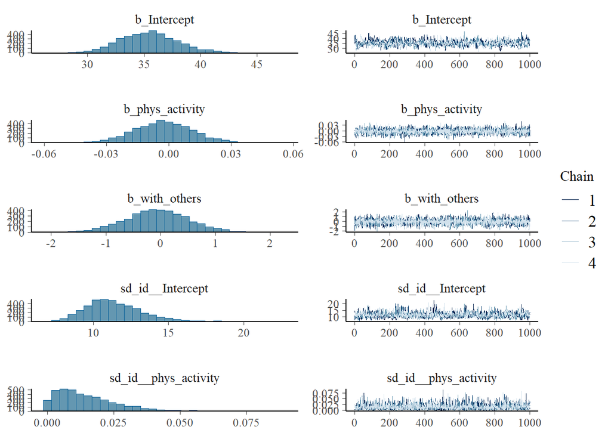

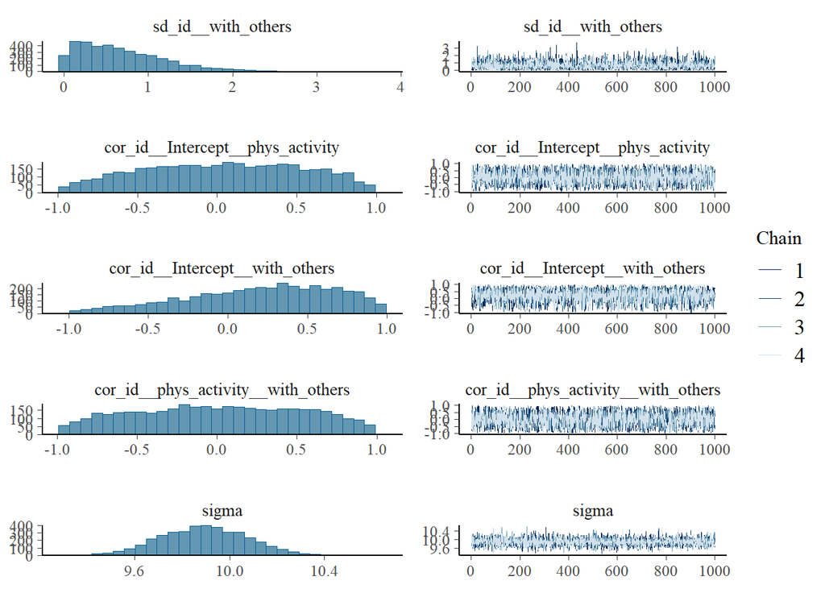

```r
plot(bm2)
```

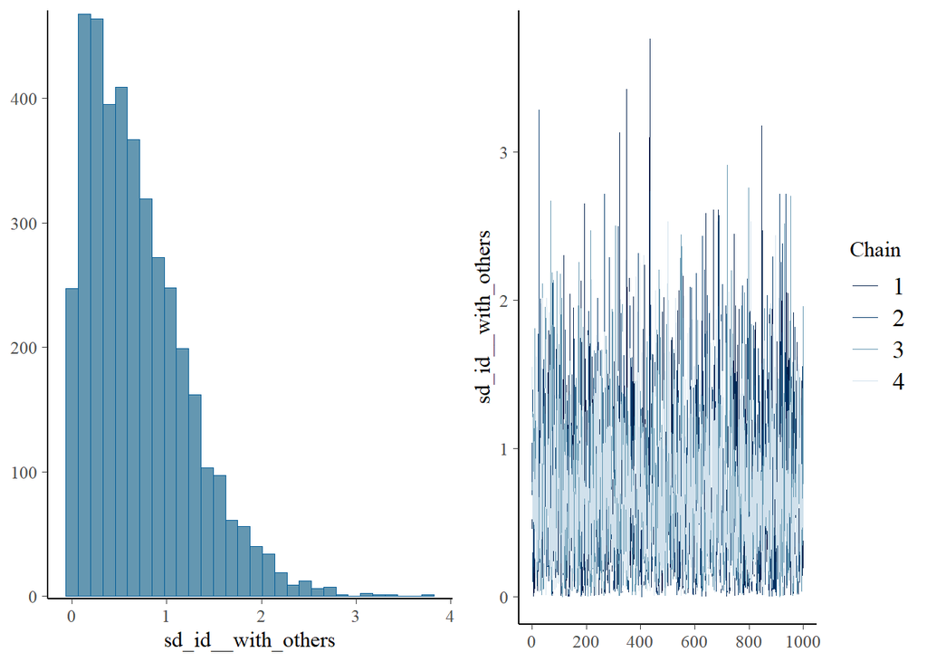

```r
#two pages of plots

#easier to plot specific variables
plot(bm2,variable = "sd_id__with_others")
```

### posterior prediction

for 2 individuals

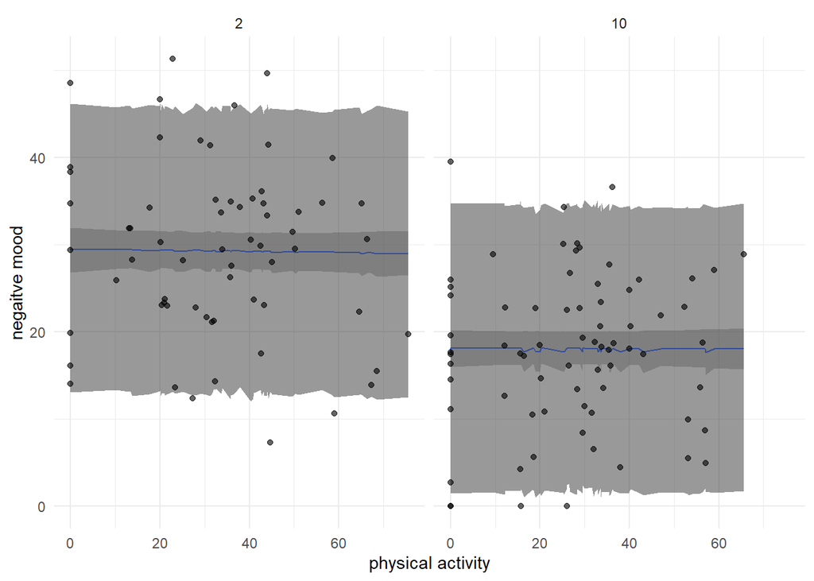

```r
nd =d %>%
  filter(id %in% c(10,2)) %>%
  select(id, phys_activity, negative_mood,with_others)

bm2_preds = bind_cols(
  # fitted, i.e., the data that the model fit to
  fitted(bm2, newdata = nd,probs = c(0.05, 0.95)) %>%
    data.frame(),
  # predict, the posterior prediction
  predict(bm2, newdata = nd,probs = c(0.05, 0.95)) %>%
    data.frame() %>%
    #some renaming:
    select(Q5:Q95) %>%
    setNames(c("p_lower", "p_upper"))) %>%
  bind_cols(nd)

ggplot(data=bm2_preds,aes(x = phys_activity)) +
  geom_smooth(aes(y = Estimate, ymin = Q5, ymax = Q95),
              stat = "identity", alpha = 1/2, linewidth = 1/2) +
  geom_ribbon(aes(ymin = p_lower, ymax = p_upper),alpha = 1/2) +
  geom_point(aes(y = negative_mood),alpha=0.6) +
  ylab("negaitve mood") + xlab("physical activity")+
  scale_y_continuous(breaks = seq(0, 100, 20))+
  facet_wrap(~ id)+theme_minimal()
```

for a new individual, informed by variance in random effects

```r
bm2_epred = bm2 %>%
    emmeans(~ phys_activity + with_others ,
            at = list(phys_activity = seq(0,100,5),
                      with_others = c(0,1),
                      id = "IDX"),
            epred = TRUE, re_formula = ~ (1 + phys_activity + with_others|id),
            allow_new_levels = TRUE, sample_new_levels = "uncertainty") %>%
    gather_emmeans_draws()
```

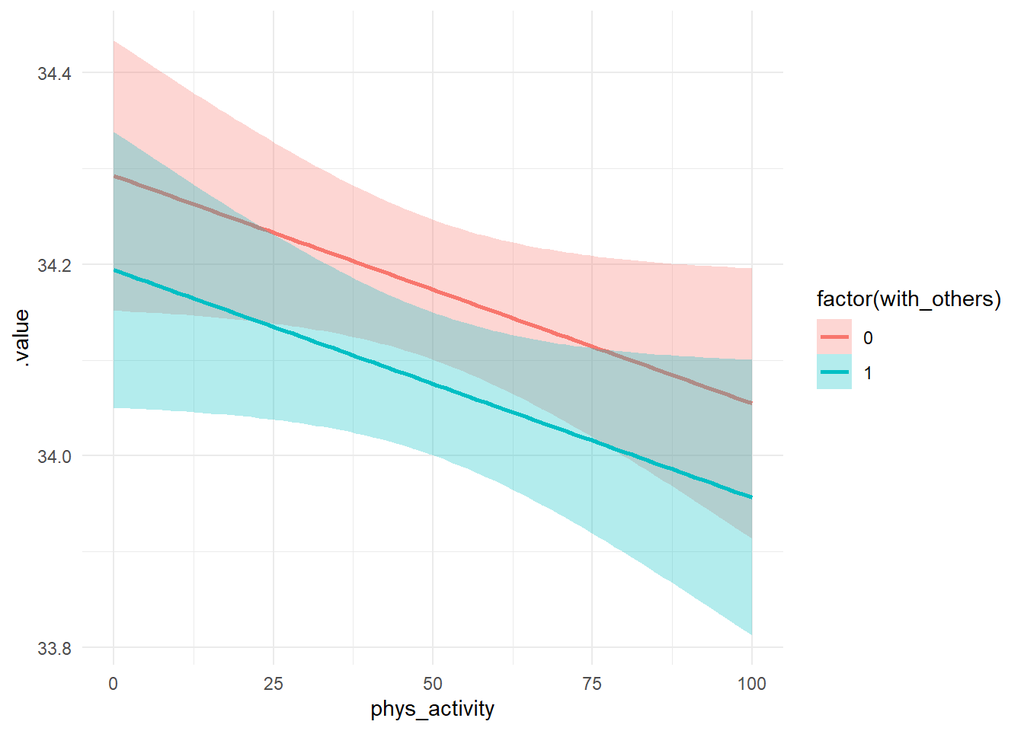

```r
ggplot(bm2_epred, aes(x = phys_activity, y = .value, group = factor(with_others),
                      colour = factor(with_others), fill = factor(with_others))) +
  geom_smooth(method = "lm", se = TRUE, size = 1, alpha = 0.3) + theme_minimal()
```

# Bonus: zero-inflated beta model

research question: how is positive affect associated with physical activity

data preparation: we will use a beta distribution, which needs the response values to be between 0 and 1.

```r
#scaling to between 0 and 1
d$phys_activity01 = d$phys_activity/100

# changing 1s to 0.999
d$phys_activity01 = ifelse(d$phys_activity01==1, 0.999, d$phys_activity01)
```

## exploration

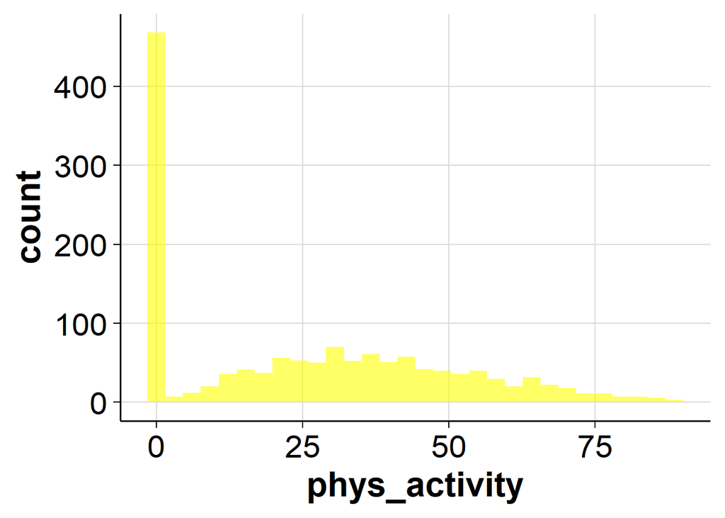

```r
ggplot(d,aes(x=phys_activity,fill=T))+geom_histogram(size=2,alpha=0.6,fill="yellow")+theme_ppt()
```

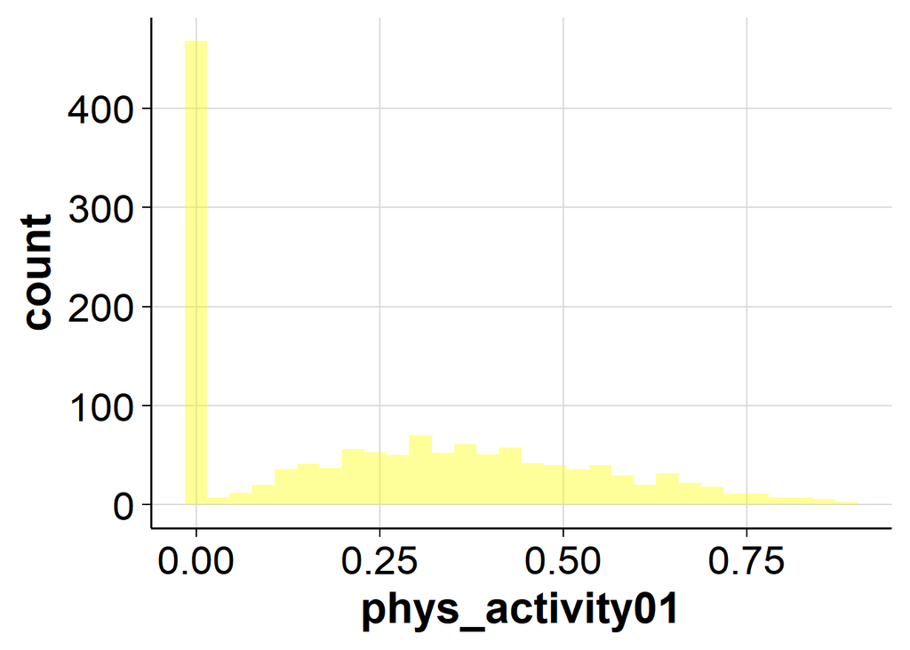

```r
ggplot(d,aes(x=phys_activity01,fill=T))+geom_histogram(size=2,alpha=0.4,fill="yellow")+theme_ppt()
```

We see a lot of zeros, which we can model with a zero-inflation component. This adds probability mass at 0 to the target of the sampling algorithm. Considering the underlying data-generating process, this distribution can also be justified.

```r
#look at the implementation of zero-inflated beta:
?brmsfamily
#zero_inflated_beta(link = "logit", link_phi = "log", link_zi = "logit")
```

## finding priors

```r
get_prior(phys_activity ~ positive_mood + (1 + positive_mood|id),
           zi ~ 1 + (1|id),
          family=zero_inflated_beta(),
          data=d)
```

| prior | class | coef | group | resp | dpar | nlpar | lb | ub | source |
| --- | --- | --- | --- | --- | --- | --- | --- | --- | --- |
|  | b |  |  |  |  |  |  |  | default |
|  | b | positive_mood |  |  |  |  |  |  | default |
| lkj(1) | cor |  |  |  |  |  |  |  | default |
|  | cor |  | id |  |  |  |  |  | default |
| student_t(3, 0, 2.5) | Intercept |  |  |  |  |  |  |  | default |
| gamma(0.01, 0.01) | phi |  |  |  |  |  | 0 |  | default |
| student_t(3, 0, 2.5) | sd |  |  |  |  |  | 0 |  | default |
|  | sd |  | id |  |  |  |  |  | default |
|  | sd | Intercept | id |  |  |  |  |  | default |
|  | sd | positive_mood | id |  |  |  |  |  | default |

[output cut: 1 more lines]

```r
plogis(0)
```

```
## [1] 0.5
```

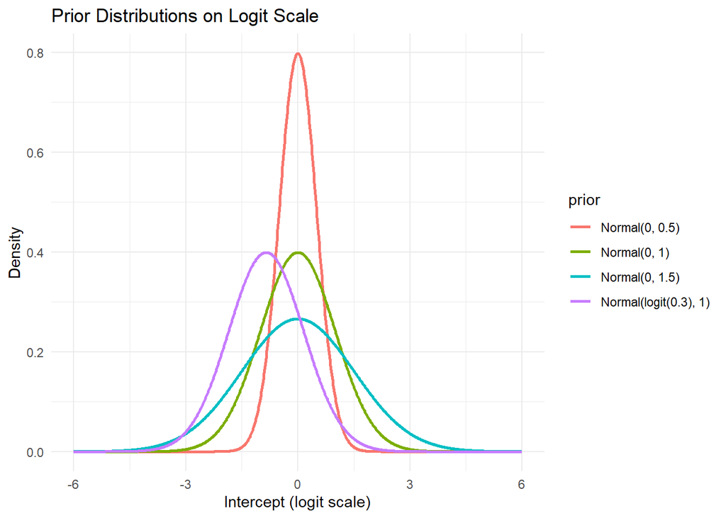

```r
#same
#inv_logit_scaled(0)

# Define a sequence of logit-scale values
x = seq(-6, 6, length.out = 1000)

# Define different priors for the intercept
priors = list(
  "Normal(0, 1.5)"  = dnorm(x, mean = 0, sd = 1.5),
  "Normal(0, 1)"   = dnorm(x, mean = 0, sd = 1),
  "Normal(0, 0.5)" = dnorm(x, mean = 0, sd = 0.5),
  "Normal(logit(0.3), 1)" = dnorm(x, mean = qlogis(0.3), sd = 1)
)

# Convert to data frame for ggplot
df = do.call(rbind, lapply(names(priors), function(name) {
  data.frame(
    x = x,
    density = priors[[name]],
    prior = name)}))

# Plot densities on logit scale
p1 = ggplot(df, aes(x = x, y = density, colour = prior)) +
  geom_line(size = 1) +
  labs(x = "Intercept (logit scale)", y = "Density",
       title = "Prior Distributions on Logit Scale") +
  theme_minimal()

# Also plot transformed probabilities
df$prob = plogis(df$x)

p2 = ggplot(df, aes(x = prob, y = density, colour = prior)) +
  geom_line(size = 1) +
  labs(x = "Intercept (probability scale)", y = "Density",
       title = "Prior Distributions on Probability Scale") +
  theme_minimal()

p1
```

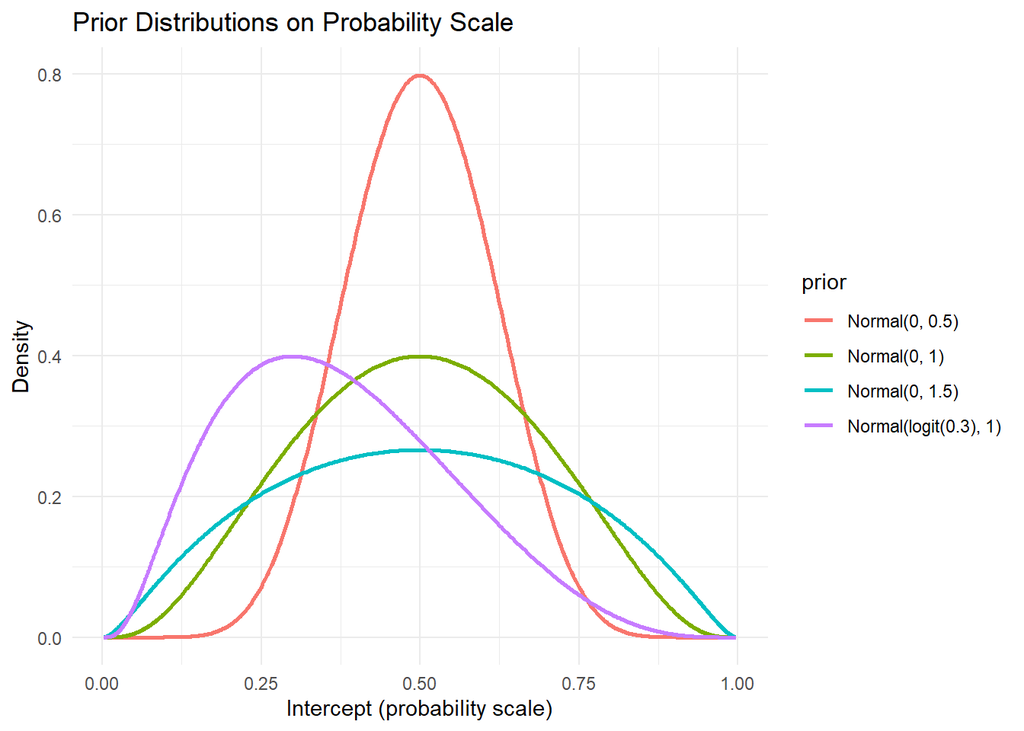

```r
p2
```

```r
priors_zi_beta = c(
          # Intercept  and coefficients on logit-scale -> use same prior as for logistic regression
          prior(normal(0,1),class=Intercept),
          prior(normal(0,1),class=b),
          # precision phi on log-scale, difficult to have intuition for that -> use flat defaults
          #prior(gamma(0.01, 0.01),class=phi),
          # zero inflation part
          prior(normal(logit(0.3), 1), class =  zi),
          #random effects covariance
          prior(student_t(3, 0, 2.5),class=sd),
          prior(lkj_corr_cholesky(1), class = cor))
```

### testing the priors

with the rescaled response variable

```r
bm3_prior <- brm(
            phys_activity01 ~ positive_mood + (1 + positive_mood|id),
            zi ~ 1 + (1|id),
    family=zero_inflated_beta(),
    data=d,
    prior = priors_zi_beta,
    sample_prior = "only",   # only sampling from prior
    iter = 2000, chains = 4, seed = 123,
    file="bm3_prior",file_refit="on_change")
summary(bm3_prior)
```

```
##  Family: zero_inflated_beta
##   Links: mu = logit; phi = identity; zi = identity
## Formula: phys_activity01 ~ positive_mood + (1 + positive_mood | id)
##          autocor ~ tructure(list(), class = "formula", .Environment = <environment>)
##    Data: d (Number of observations: 1397)
##   Draws: 4 chains, each with iter = 2000; warmup = 1000; thin = 1;
##          total post-warmup draws = 4000
##
## Multilevel Hyperparameters:
## ~id (Number of levels: 20)
##                              Estimate Est.Error l-95% CI u-95% CI Rhat Bulk_ESS
## sd(Intercept)                    2.79      2.95     0.10    10.81 1.00      890
## sd(positive_mood)                2.83      3.35     0.10    10.99 1.00      986
## cor(Intercept,positive_mood)    -0.01      0.58    -0.95     0.95 1.01      625
##                              Tail_ESS
## sd(Intercept)                     630
## sd(positive_mood)                 560
## cor(Intercept,positive_mood)      720
##
## Regression Coefficients:
##               Estimate Est.Error l-95% CI u-95% CI Rhat Bulk_ESS Tail_ESS
## Intercept        -3.22     55.24  -113.92   104.52 1.00      931     1554
## positive_mood     0.06      0.98    -1.88     2.03 1.00      931     1535
##
## Further Distributional Parameters:
##     Estimate Est.Error l-95% CI u-95% CI Rhat Bulk_ESS Tail_ESS
## phi     0.51      4.85     0.00     2.08 1.01      553     1092
## zi      0.39      0.27     0.01     0.94 1.00     1010      784
##
## Draws were sampled using sampling(NUTS). For each parameter, Bulk_ESS
## and Tail_ESS are effective sample size measures, and Rhat is the potential
## scale reduction factor on split chains (at convergence, Rhat = 1).
```

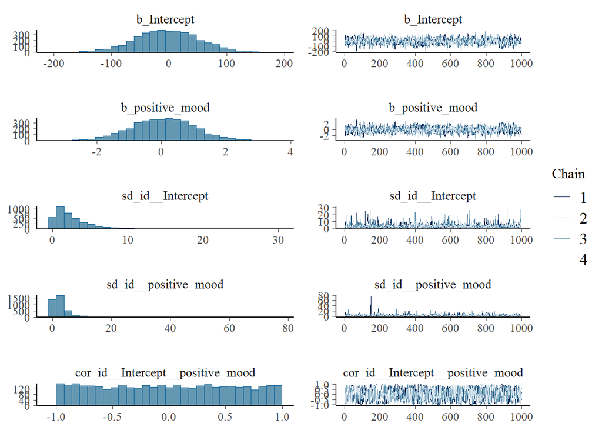

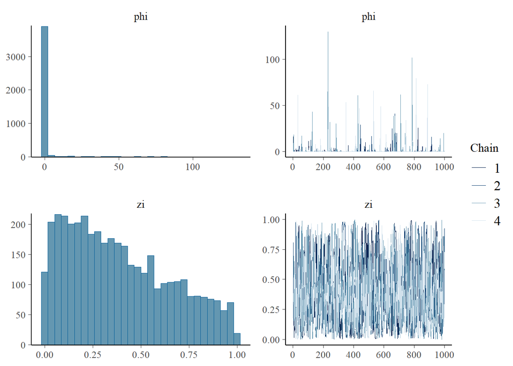

```r
plot(bm3_prior)
```

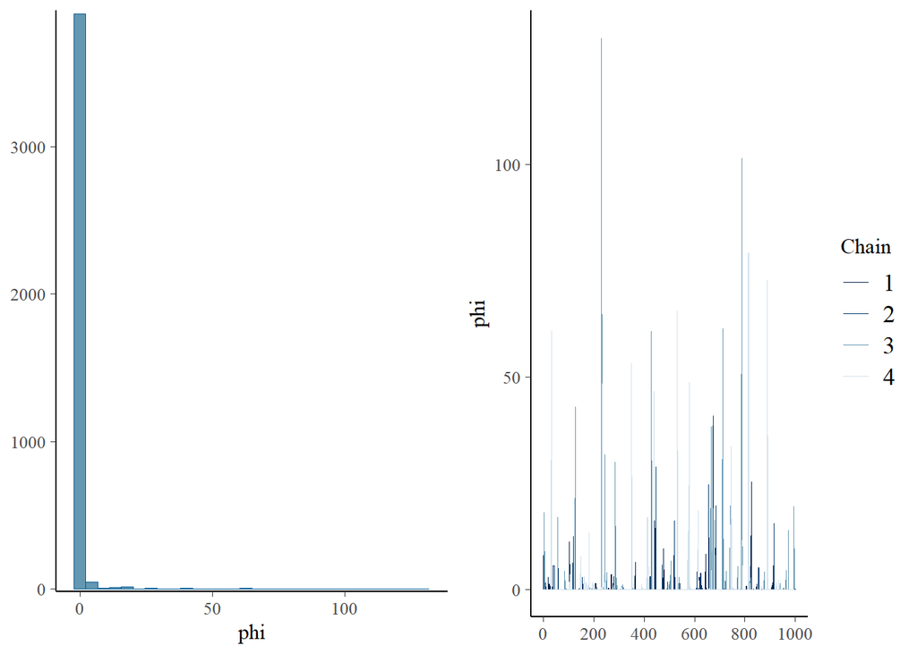

```r
#example of problematic chains:
plot(bm3_prior,variable = "phi")
```

trying again with prior for phi too

[figure not shown]

```r
x = seq(0, 50, length.out = 1000)
y = dgamma(x, shape = 2, rate = 0.1)

ggplot(data.frame(x, y), aes(x, y)) +
  geom_line(size = 1) +
  labs(title = "gamma(0.1, 0.1) prior for phi",
       x = "phi", y = "Density") +
  theme_minimal()
```

```r
priors_zi_beta2 = c(
          # Intercept and coefficients on logit-scale -> use same prior as for logistic regression
          prior(normal(0,1),class=Intercept),
          prior(normal(0,1),class=b),
          # precision phi on log-scale, difficult to have intuition for that -> use flat defaults
          prior(gamma(2, 0.01),class=phi),
          # zero inflation part
          prior(normal(logit(0.3), 1), class =  zi),
          #random effects covariance
          prior(student_t(3, 0, 2.5),class=sd),
          prior(lkj_corr_cholesky(1), class = cor))
```

```r
bm3_prior2 <- brm(
            phys_activity01 ~ positive_mood + (1 + positive_mood|id),
            zi ~ 1 + (1|id),
    family=zero_inflated_beta(),
    data=d,
    prior = priors_zi_beta2,
    sample_prior = "only",   # only sampling from prior
    iter = 2000, chains = 4, seed = 123,
    file="bm3_prior2",file_refit="on_change")
```

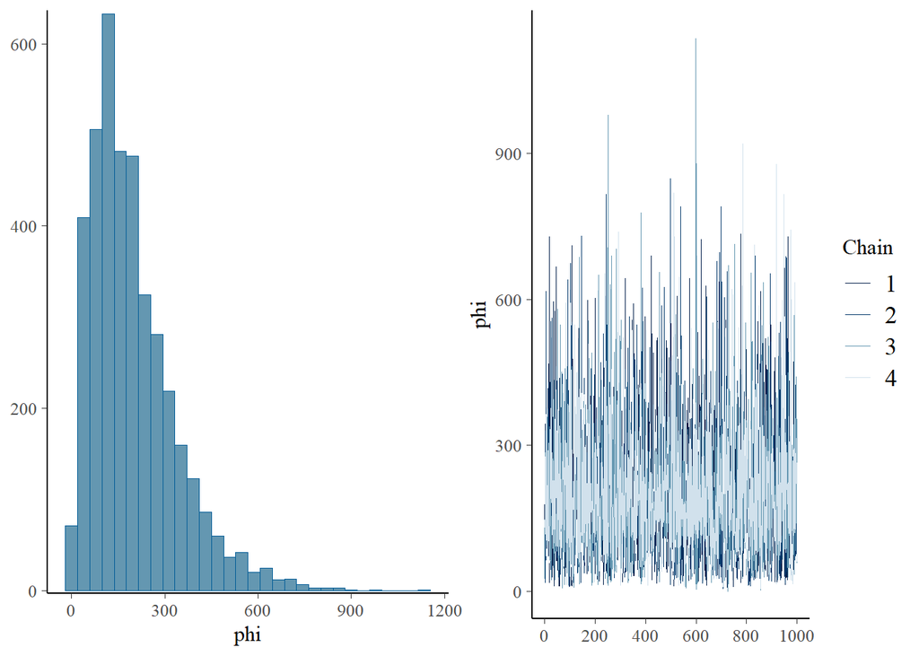

```r
plot(bm3_prior2,variable = "phi")
```

much better mixing of chains

## fitting

```r
bm3 <- update(bm3_prior2,
    iter = 2000, chains = 4, seed = 123,
    file="bm3",file_refit="on_change")
summary(bm3)
```

```
##  Family: zero_inflated_beta
##   Links: mu = logit; phi = identity; zi = identity
## Formula: phys_activity01 ~ positive_mood + (1 + positive_mood | id)
##          autocor ~ tructure(list(), class = "formula", .Environment = <environment>)
##    Data: d (Number of observations: 1397)
##   Draws: 4 chains, each with iter = 2000; warmup = 1000; thin = 1;
##          total post-warmup draws = 4000
##
## Multilevel Hyperparameters:
## ~id (Number of levels: 20)
##                              Estimate Est.Error l-95% CI u-95% CI Rhat Bulk_ESS
## sd(Intercept)                    2.82      3.89     0.08    10.29 1.00     5536
## sd(positive_mood)                2.73      3.10     0.10     9.99 1.00     5089
## cor(Intercept,positive_mood)     0.01      0.58    -0.95     0.95 1.00     5966
##                              Tail_ESS
## sd(Intercept)                    1834
## sd(positive_mood)                2054
## cor(Intercept,positive_mood)     2474
##
## Regression Coefficients:
##               Estimate Est.Error l-95% CI u-95% CI Rhat Bulk_ESS Tail_ESS
## Intercept         0.58     54.43  -105.31   107.58 1.00     6931     3449
## positive_mood    -0.01      0.97    -1.92     1.89 1.00     6937     3451
##
## Further Distributional Parameters:
##     Estimate Est.Error l-95% CI u-95% CI Rhat Bulk_ESS Tail_ESS
## phi   198.12    138.87    24.52   554.60 1.00     4323     2398
## zi      0.39      0.27     0.01     0.94 1.00     4453     2575
##
## Draws were sampled using sampling(NUTS). For each parameter, Bulk_ESS
## and Tail_ESS are effective sample size measures, and Rhat is the potential
## scale reduction factor on split chains (at convergence, Rhat = 1).
```

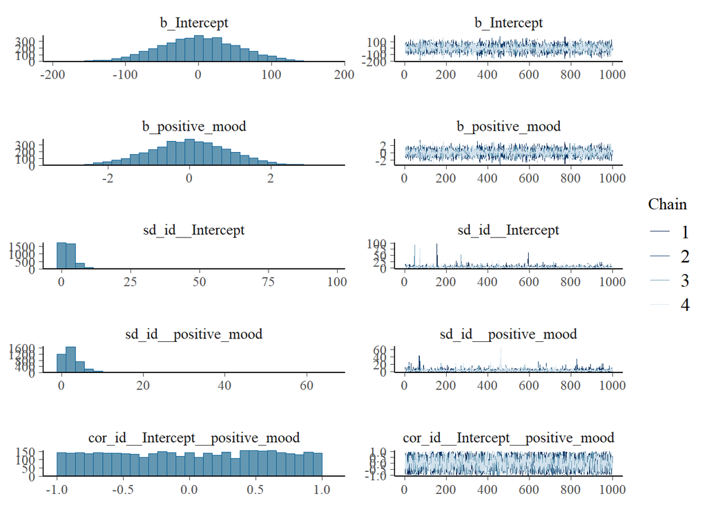

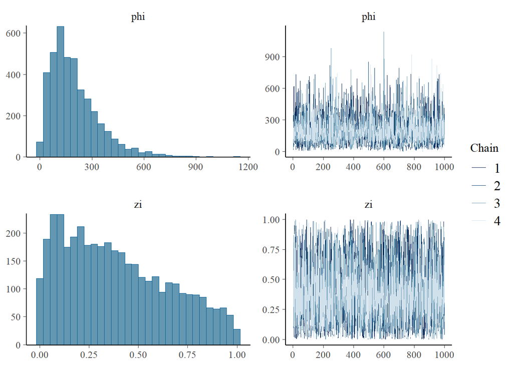

```r
plot(bm3)
```

# —————————————————————————-

# logistic regression

research question: are participants more likely to be with others later in the day?  
The model: with_others ~ 1 + prompt + (1 + prompt | id) *If you want to add random effects. Feel free to leave them out or add another factor. Maybe try solving the exercise first without random effects and then adding them later.*

## data exploration

```r
# e.g.
#ggplot(d, aes(x=with_others,fill=factor(prompt)))+geom_bar()+theme_ppt()
```

Note: For the logistic regression, use the likelihood function bernoulli() in the family argument. A bernoulli process is drawing either 0 or 1 only once, which is what we need for the logistic regression. See the documentation under bernoulli:

```r
?brmsfamily
```

Note the link function used there.

## finding priors

(you can reuse the priors from the logit-part of the zero_inflated_beta regression above)

```r
get_prior( ...,
           family = ...,
           data = d)


priors_logit = c(
      prior = ...,
      prior = ...
                )
```

### testing the priors

```r
bm4_prior = brm( ...,
           family = ...,
           prior = priors_logit,
          data = d,
          sample_prior = "only",   # only sampling from prior
          iter = 1000, chains = 4, seed = 123,
          file="bm4_prior",file_refit="on_change")

plot(bm4_prior)

pp_check(bm4_prior)
```

## fitting the model

```r
#update bm4_prior, removing the sample_prior line, changing the file name, adapting the iterations
```

## diagnostics

```r
# look at Rhat and ESS
#look at the chains
```

## interpret

```r
#look at the summary output, remember that it's on the log-odds scale.
# use exp() if you want to transform values to the odds scale
```

# —————————————————————————-